# How Does Quantum Spins Behave in a Magnetic Field?

Building Our Classical Model of Quantum Spin and Larmor Precession

## *Expected Learning Outcomes*

*At the end of this module, students should be able to…*

1. *describe what is observed without trying to explain, both in words and by means of a picture of the experimental setup ([Scientific Ability B5](https://sites.google.com/site/scientificabilities/rubrics))*
2. *design a reliable experiment that tests the hypothesis ([Scientific Ability C2](https://sites.google.com/site/scientificabilities/rubrics))*
3. *make a reasonable judgment about a given hypothesis based on experimental data ([Scientific Ability C8](https://sites.google.com/site/scientificabilities/rubrics))*

> **“We must be clear that when it comes to atoms, language can be used only as in poetry.”**

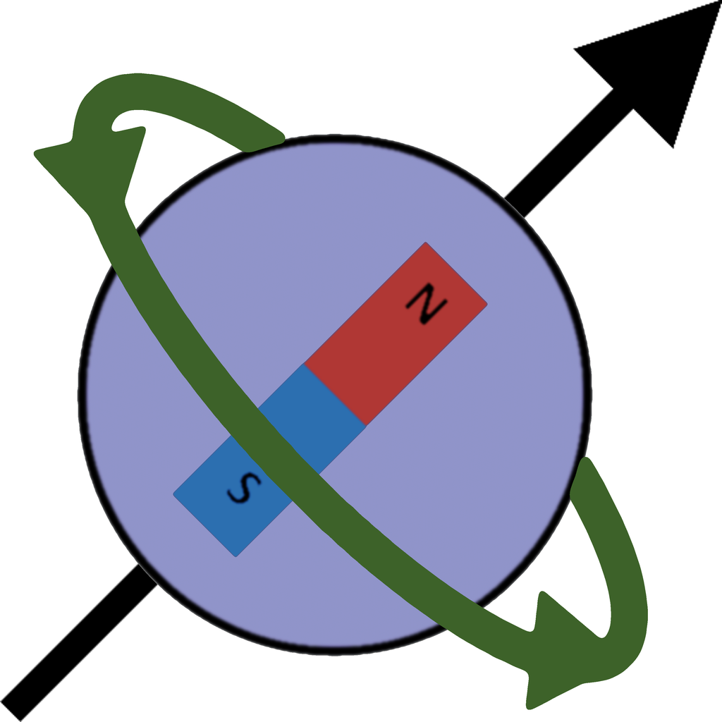

**quantum spin** - a property of quantum particles that has many mathematical similarities to macroscopic spinning objects but also has unique quantum properties not observed in the macroscopic realm

**elementary particles** - subatomic particles that make up all known matter and cannot be divided any further into constituent parts

# Background Information

The **quantum spin** of a particle is one of the few physical properties that uniquely identify an **elementary particle** (along with information like mass and electric charge). We have seen that quantum spin is quantized and allows atoms and subatomic particles to interact with an external magnetic field. In this module, we’ll explore more in depth the behavior of quantum spins in a magnetic field in order to build up a classical analog of quantum spin that will be useful in making sense of the physics behind magnetic resonance in later modules.

For the activities below, we will be making use of an [apparatus](https://www.teachspin.com/magnetic-torque) that provides a physical model of a quantum spin that has been designed to have many of the same dynamical behavior as real quantum spins, despite being a very classical, macroscopic object. Using this apparatus, we will explore important physical aspects of quantum spin and its behavior in an external magnetic field.

# Observation Experiment - What does spin got to do with it?

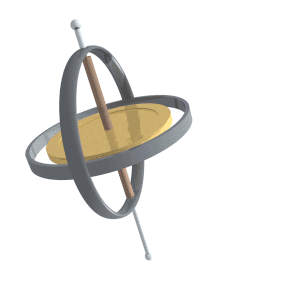

Gyroscope precession. Lucas Vieira, Public domain, via [Wikimedia Commons](https://commons.wikimedia.org/wiki/File:Gyroscope_precession.gif).

Let’s observe the behavior of a top that is set on its point without spinning and then started off at its point with spinning. We want to write down everything we observe in both cases, and try not to write comments or explanations for what is observed. We are going to want to develop our model of spin from the ground up, and try our best not to introduce any prior knowledge or assumptions that do not come directly from our observations

## Class-Wide Discussion

- What do we observe when the top is set on its point without spinning?
- What do we observe when the top is set on its point with spinning?
- Observe the behavior of our physical model of quantum spin. Does it behave more like a spinning object or non-spinning object?

**angular momentum** - a physical quantity related to how much stuff is spinning about some axis of rotation and how fast it is spinning

# The Spinning Aspects of Quantum Spin

The name ‘spin’ comes about due to some of the mathematical similarities of quantum spin behavior and macroscopic spinning objects. Most notably both types of ‘spin’ seem to have some form of **angular momentum**. In fact, quantum spin is often referred to as ‘intrinsic angular momentum’.

**vector** - a mathematical quantity that has both a magnitude and direction and is usually visualized using an arrow; vector quantities will be denoted with little arrows on top, like $\vec{A}$

**axis of rotation** - a straight line through all points in a rotating object that remain stationary; often where the axle of a rotating object is placed (e.g. through the center of a bike wheel)

## Angular Momentum

In classical physics, angular momentum is a **vector** typically denoted by $\vec{L}$ and represented by an arrow that points along the **axis of rotation**. The direction the angular momentum arrow points is determined by whether the object is rotating clockwise or counterclockwise and can be found by using the **right-hand rule**, shown in the figure below.

**right-hand rule** - make a thumbs up with your right hand and rotate your hand so that your fingers curl in the direction of rotation of the spinning object (e.g. as if the tips of your fingers were the head of the rotation arrow); your thumb now points in the direction of the angular momentum $L$; Image adapted from ([1](https://cnx.org/contents/BB7_sFuI@10/Gyroscopic-Effects-Vector-Aspects-of-Angular-Momentum))

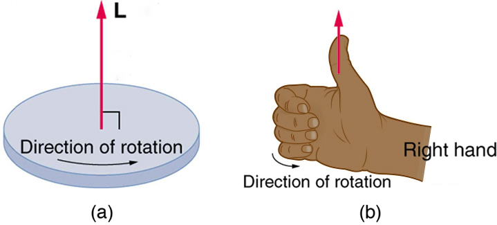

## Spin Angular Momentum

> Commonly denoted by $\vec{S}$, which is a **vector** that has the same dimensions as angular momentum, but typically will be written in terms of $\hbar = h/2\pi$ where h is Planck’s constant *(If you see an $h$ of $\hbar$ anywhere, it is a sure sign you are dealing with quantum behavior!)*

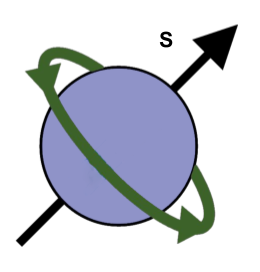

For a quantum spins, this angular momentum vector is replaced with the spin angular momentum vector, $\vec{S}$. As a helpful visualization of quantum spins, we will use a rotating sphere, and have an arrow with the spin angular momentum vector that depicts the spin direction. It is important to point out that despite this helpful visualization, there is not an actual particle actually spinning at the quantum level. Unfortunately, there are no perfect classical models that encapsulate all the full weirdness of quantum particles!

## Guided Inquiry Questions

1. Many people use ‘spin’ to refer to either the spin quantum number or the spin angular momentum vector. If I were to tell you the spin of a particular electron is $\hbar/2$, which aspect of spin am I talking about?
2. Draw a picture of a spin rotating in the opposite direction to the one shown above. *Make sure to draw the $\vec{S}$ arrow pointing in the correct direction using the right-hand rule!*
3. Based on the behavior observed of our physical model of a quantum spin, do you think it is safe to say that it has some angular momentum and that angular momentum is an important factor to explaining the dynamical behavior observed?

# Testing Experiment - What causes the quantum spin to interact with magnetic field?

We have seen that a key aspect of quantum spin is that it interacts with an external magnetic field. In this activity, we want to explore if we need to add something beyond angular momentum to our classical analog of quantum spin to why our physical model of a quantum spin (the white cue ball) behaves the way it does in a magnetic field.

> **Observation Experiment** Compare how the physical model of quantum spin (white cue ball) and a regular red snooker ball behaves in the presence of a magnetic field (without spinning the balls).

## Guided Inquiry Questions

4. Describe (using both words and pictures) what you observe of the behavior of both the white cue ball and red snooker ball in the presence of a magnetic field without any spinning.
5. List some different explanations for why our physical model of a quantum spin (white cue ball) can interact with a magnetic field. *Some explanations may seem more plausible than others, but list all the explanations you can think of, since we don’t know what the correct answer may turn out to be, since the correct explanation may not be the most obvious one!*
6. Pick one of your explanations (this will become your *hypothesis*) and design an experiment that you could perform with the white cue ball to either support or disprove your hypothesis.
7. If your hypothesis is correct, and you performed your chosen experiment, what would you predict to observe?
8. If you ultimately observed something different than your prediction, what would that tell you about your hypothesis?
9. Perform your experiment and/or watch some of the videos of the different experiments students have performed. Based on the experimental results, what is your judgment about your specific hypothesis?
10. Based on the experimental results from the different experiments being performed, is there a particular hypothesis that you think provides the best explanation of why the white cue ball interacts with a magnetic field? (Please explain by referencing the experimental results.)

**magnetic moment** - also known as magnetic dipole moment or magnetic dipole; the magnetic strength and orientation of a magnet or other object that produces a magnetic field

**dipole** - two poles (e.g. the north and south pole of a magnet); often contrasted with monopole - one pole - (e.g. a positive electric charge would be considered an electric monopole)

# The Magnetic Aspects of Quantum Spin

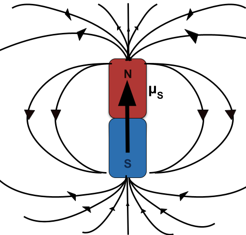

Physical objects can also have magnetic properties, which is encapsulated in the **magnetic moment** of the object. This is sometimes also called a magnetic **dipole** moment or magnetic dipole. The magnetic dipole moment can be visualized as an arrow that points from the south pole to the north pole of a tiny, little bar magnet. Essentially, the arrow representing the magnetic moment is aligned with the magnetic field it produces. The convention is that the magnetic field lines point away from the north pole and loop back to point towards the south pole, as shown in the figure in the margin.

*FUN FACT!* No matter how you cut up a magnet, you always get two poles in the remaining pieces, and the intrinsic magnetic moment of fundamental particles is a magnetic dipole. Magnetic monopoles have never been found in nature, though scientists have searched for them because they would bring a nice symmetry to the laws of physics and have some pretty nifty physical properties. You can read more about magnetic monopoles [here](https://www.forbes.com/sites/startswithabang/2021/09/03/ask-ethan-what-impact-could-magnetic-monopoles-have-on-the-universe/?sh=2a523b236818).

**gyromagnetic ratio** - a constant for a particular quantum spin that directly relates the spinning (*gyro*) aspects of quantum spin with the magnetic aspects

## Spin Magnetic Moment

Elementary particles can also have magnetic moments, including an intrinsic magnetic moment caused by the particle’s spin. This is very cleverly called the spin magnetic moment of the particle and denoted by $\mu_\textrm{S}$. There is a very simple and direct relationship between the spin magnetic moment and the spin angular momentum $S$ of the particle:

$$\vec{\mu}_\textrm{S} = \gamma
\vec{S}$$
where $\gamma$ is a constant called the **gyromagnetic ratio** and has particular values for each type of particle. This simple expression shows that if you know the spin angular momentum and the gyromagnetic ratio of the particle, you can easily calculate its spin magnetic moment. But even more importantly for our purposes, this equation tells us that the spin magnetic moment is always aligned (pointing in the same direction) or anti-aligned (pointing in exactly the opposite direction) with the spin angular momentum, depending on the sign of the gyromagnetic ratio.

Thus we can complete our full visualization of a quantum spin which contains both the spin magnetic moment and the spin angular momentum.

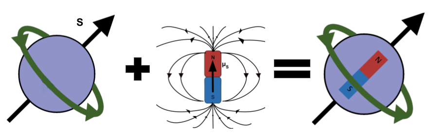

## Guided Inquiry Questions

8. In the visualization of a quantum spin given above with both the spin magnetic moment (as a bar magnet) and the spin angular momentum, is the gyromagnetic ratio positive or negative? How can you tell?
9. Draw your own visualization of a quantum spin with a negative gyromagnetic ratio. *Feel free to have it rotate in any direction, but make sure to draw the $\vec{S}$ arrow pointing in the correct direction using the right-hand rule!*

# Exploratory Experiment - What determines the frequency of precession of a quantum spin?

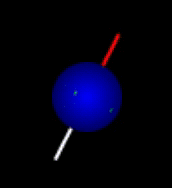

Larmor precession. Image source ([2](https://www.drcmr.dk/images/sph_precess.gif)).

**precession** - the circular motion of the axis of rotation of a spinning body around another axis

You may have noticed that both a top and our physical model of a spin will have some interesting motion when the axis of rotation is not perfectly aligned with the vertical direction. Instead of the axis of rotation remaining stationary, it will slowly start moving around in a horizontal circle. This behavior is called **precession**. The precession frequency - how many cycles the axis of rotation makes each second - actually can provide us useful information about the quantum spin (more on that later!). But first, let’s explore what *causes* precession in our physical model of quantum spin.

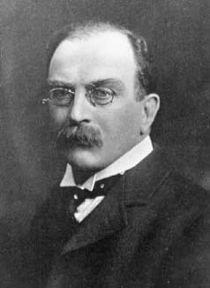

Image source ([3](https://en.wikipedia.org/wiki/Joseph_Larmor#/media/File:Joseph_Larmor.jpeg))

**Sir Joseph Larmor** - Among his many contributions to theoretical physics, Larmor created the first solar system model of the atom in 1897, postulated the proton (calling it a “positive electron”), and explained the splitting of the spectral lines in a magnetic field by the oscillation of electrons given rise to the Larmor precession frequency.

# Larmor Precession

The precession of a quantum spin is called Larmor precession and is simply dictated by only a few parameters: the gyromagnetic ratio of the spin, $\gamma$, and the strength of the magnetic field, $B$. The frequency of Larmor precession $f$ is given by:

$$f = \gamma B,$$
when the gyromagnetic ratio given is in units of frequency (typically megahertz, MHz) divided by magnetic field strength (typically Tesla, T). Each quantum spin has a unique gyromagnetic ratio, $\gamma$, and thus a unique precession frequency when placed in the same strength magnetic field.

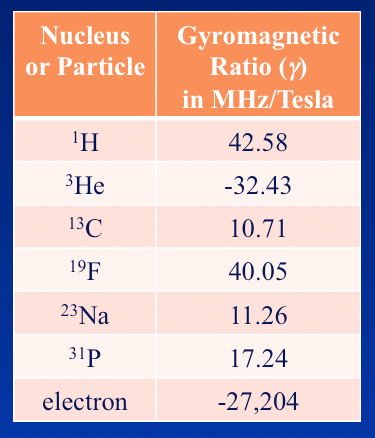

Image source ([4](https://mriquestions.com/gyromagnetic-ratio-gamma.html))

## Guided Inquiry Questions

13. In the apparatus we have been using, the magnet current in the magnet coils are directly proportional to the magnetic field strength (e.g. if you took the current value and multiplied it by a particular constant, you would get the magnetic field strength, $B$.) If you doubled the magnet current, what would you expect to happen to the magnetic field strength? What would happen to the precession frequency?
14. Do your conclusions from your precession experiments above appear to agree with the Larmor precession frequency equation given for a quantum spin? Explain.
15. What precession frequency would you expect for $^1$H in a 2-T magnetic field? What precession frequency would you expect for an electron in the same magnetic field? What does the negative sign mean?
16. If you observed a Larmor frequency of 80.1 MHz in a 2 T magnetic field, which nucleus are you likely observing?

# Reflection Questions